# Descriptive Analysis of network graph characteristics

Questions about structures or characteristics of a network graph: * Paths of graphs, flows of commodities * important nodes as centrality * groups of similar vertices as graph partitioning problem

```r
library(sand)
```

```r
library(igraph)
library(ggplot2)
```

Vertex and Edge characteristics

1. Vertex Degree In a network of G = (V, E), the degree *d<sub>v</sub>* of a vertex *v* is the number of edges incident upon *v*  
   Given G, *f<sub>d</sub>* is the fraction of vertices *v* with degree *d<sub>v</sub>* = d The collection {*f<sub>d</sub>*}<sub>d>=0</sub> is called the *degree distribution of G*; it’s a rescaling of the set of degree frequencies from the original degree sequence For weighted networks, a generalization of degree is the notion of vertex *strength*, obtained by summing up all the weights of edges incident to the given vertex; its distribution is the *weighted degree distribution*,

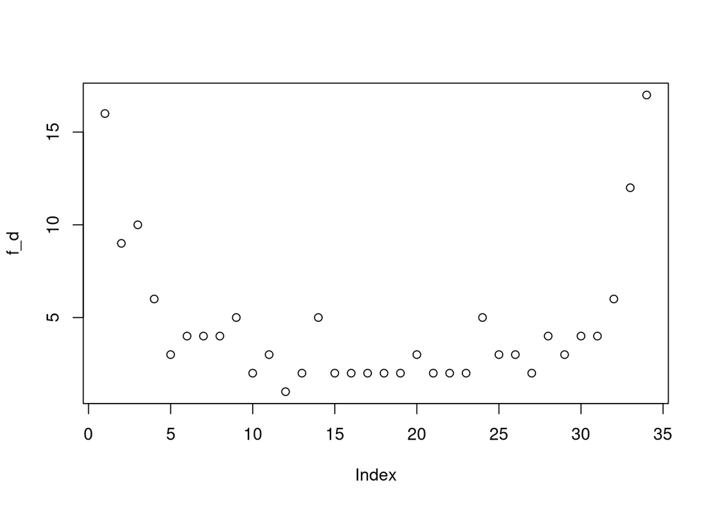

```r
data(karate)
f_d  <- degree(karate)
plot(f_d)
```

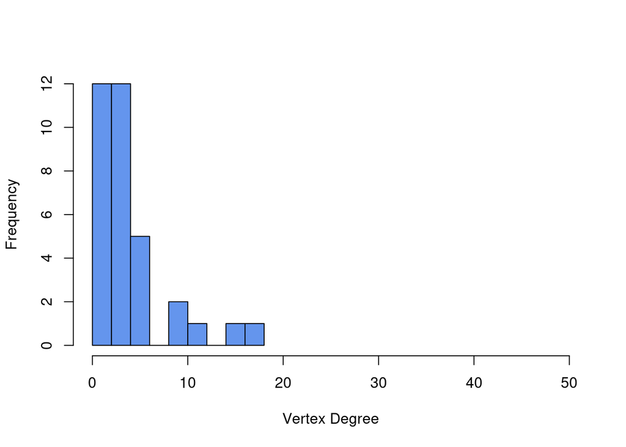

```r
hist(f_d, col="cornflowerblue", xlim=c(0,50), xlab="Vertex Degree", ylab = "Frequency", main = "")
```

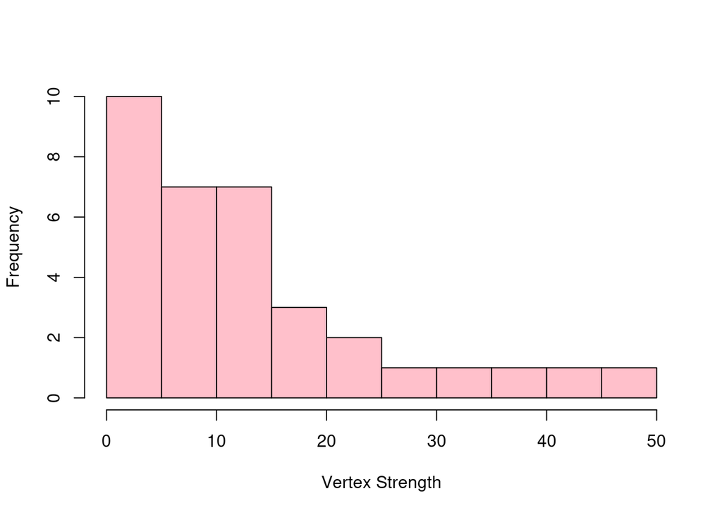

```r
w <- strength(karate)
hist(w, col="pink", xlim=c(0,50), xlab="Vertex Strength", ylab = "Frequency", main = "")
```

Shapes of degree distribution can vary greatly

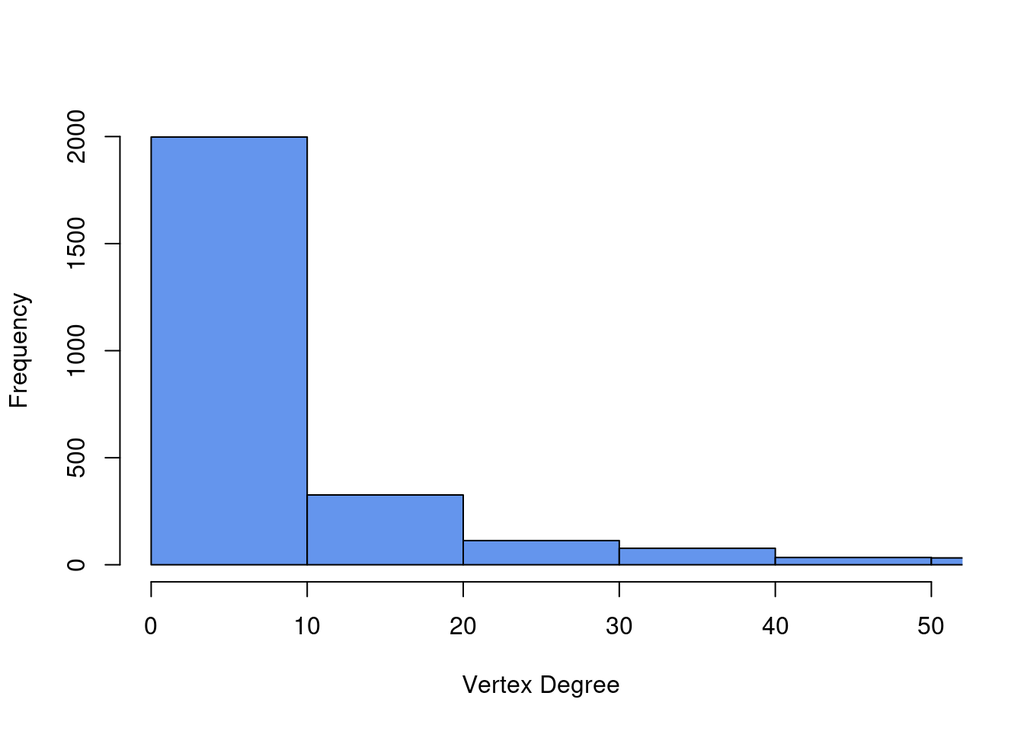

```r
data(yeast)
d.yeast <- degree(yeast)
w.yeast <- strength(yeast)
hist(d.yeast, col="cornflowerblue", xlim=c(0,50), xlab="Vertex Degree", ylab = "Frequency", main = "")
hist(w.yeast, col="cornflowerblue", xlim=c(0,50), xlab="Vertex Degree", ylab = "Frequency", main = "")
```

[output not shown]

Creating a log-scale for this distribution:

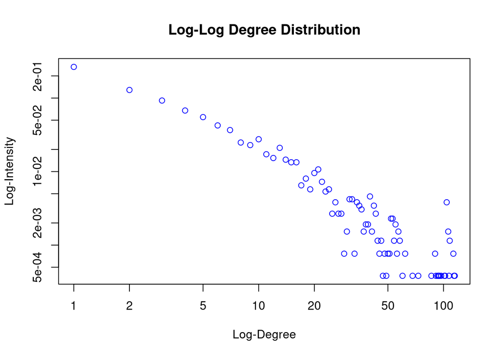

```r
dd.yeast <- degree_distribution(yeast)
d <- 1:max(d.yeast) -1
ind <- (dd.yeast != 0 )
plot(d[ind], dd.yeast[ind], log = "xy", col="blue", xlab=c('Log-Degree'), ylab=c('Log-Intensity'), main="Log-Log Degree Distribution")
```

The average degree of the *neighbors* of a vertex * e.g. vertex degree as a function of average vertex degree of neighbors * are higher degree vertices tend to connect to similar degree neighbors?

```r
a.nn.deg.yeast <- knn(yeast, V(yeast))$knn
length(a.nn.deg.yeast)
```

```
## [1] 2617
```

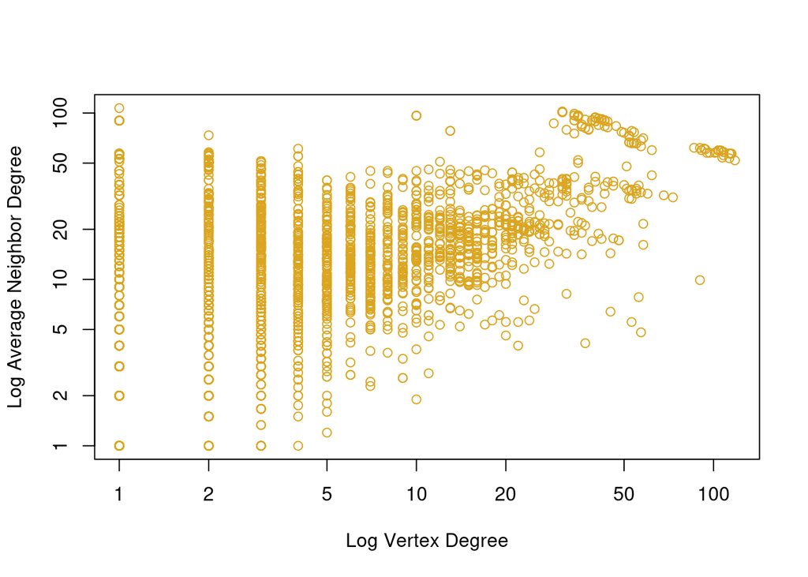

```r
plot(d.yeast, a.nn.deg.yeast, log = "xy", col="goldenrod", xlab=c('Log Vertex Degree'), ylab=c('Log Average Neighbor Degree'))
```

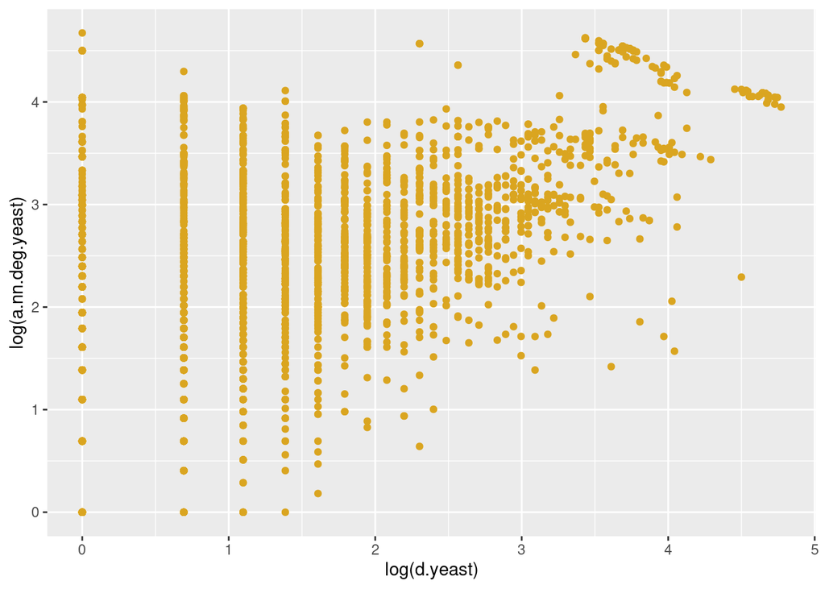

```r
ggplot() +
   geom_point(aes(x = log(d.yeast), y =log(a.nn.deg.yeast)), color = "goldenrod")
```

## Vertex Centrality

   $$c_{B}(V) = \sum_{s \neq t \neq v \in V} \frac {\sigma (s, t \mid v)} {\sigma(s, t)}$$

   where the nominator is the total number of shortest paths between s and t, which pass through v; the denominator is the total number of shortest paths between s and t.
   - mostly rescaled by division of a factor of (N_v -1) (N_v -2) /2
3. eigenvector centrality
   - the notion of ‘status’, ‘rank’ or ‘prestige’
   - the more central the neighbors are, the more central the vertex is
   - can be defined as eigenvector solutions of linear systems of equations
   - there are many eigenvector centrality measures, such as Bonacich’s:

   $$c_{E_i}(v) = \alpha \sum _{[u, v] \in E} C_{E_i}(u)$$